# R语言入门

# 1 R语言学习准备

## 1.1 **R语言的前世今生**

20世纪90年代，R语言当时被称为S语言，因研发者Ross和Robert两位学者名字首字母均为R而得名，直到现在被大家默认为R语言。在中国，R语言蓬勃生长，2018年R会议已进行到第十一届，学术高潮也持续高涨超过一个年代。

R是S语言的一种实现。S语言是由 AT&T贝尔实验室开发的一种用来进行数据探索、统计分析、作图的解释型语言。最初S语言的实现版本主要是S-PLUS。S-PLUS是一个商业软件，它基于S语言，并由MathSoft公司的统计科学部进一步完善。后来Auckland大学的Robert Gentleman 和 Ross Ihaka 及其他志愿人员开发了一个R系统。R的使用与S-PLUS有很多类似之处，两个软件有一定的兼容性。

## 1.2 **R与Rstudio**

### 1.2.1 **R语言的介绍**

R语言是一种面向数据进行处理分析的一种有规律的计算机编程+统计学的运行语言。R语言是一个开源平台，允许所有开发者去创造完善，致使R语言不断在进行改进、更新、提升。

R语言构成以英文、数字、符号、中文等名称组成的一门“统计学+数学+编程”的智慧性语言。具体细化来讲，R是一个关于包的集合，主要是涉及函数、数据集、编译器等体系。R的包可以理解成一本书，通过书的知识来完成编程、数据分析等操作。

### 1.2.2 **Rstudio的介绍**

Rstudio是R语言实现方式的一种集成环境，R借助Rstudio可以生成html、PDF等格式的文本。在该环境下，你可以切换不同的R语言版本，以此达到R不同版本的兼容效果。

## 1.3 **选择R语言的理由**

### 1.3.1 **有深度+实用性高**

R语言常在数据相关的方面解决方法不同。例如，使用R语言进行简单计算，可以直接运算，也可以赋值运算。现对a=666,b=999,c=a+b，以回车键Enter执行运算语句,得到c=1665,操作过程如下：

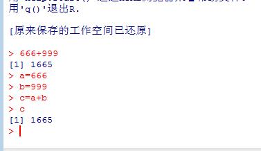

当一段文字中的某些词语出现多次，为了对它进行一个直观展示，增强视觉认知的效应。可以用R语言对文字内容进行词频分析，绘制词云图。如下图，“数据”这个词语字体越大，说明在该段文字中“数据”出现的频次越高！

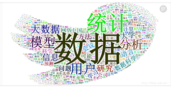

### 1.3.2 **包、函数开源**

R语言是一款开源的软件。它的包和函数等使用方法在网络上可以搜寻到相关的概念。当你对R语言中的某个函数产生困惑时，对函数名称前缀“问号”符号，就得到该函数的使用方法，操作如下：

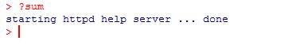

Suggest:可以用该方法去查看boxplot，pie等函数。

* install.packages(“ggplot2”) ##加载安装包

* library(help=“ggplot2”) ##查看包的使用说明（先安装，才可查看）

* .packages(all.available=T) ##查看本地电脑安装的所有包

Suggest:可以选择本地安装的包，进一步查看包的使用方法。

### 1.3.3 **R语言支持的环境**

可运行Windows系统,Linux系统,Mac OS X系统，支持交互式数据探索和分析实践。使用R语言实现对数据进行高维量级处理、数据可视化、统计模型分析、数据挖掘算法等。

# 2 R语言在学科技术领域的应用

R语言在学科技术领域应用广泛。列举以下几点：

1.R语言能对用户行为进行分析。例如，同学A想在某电商网站上买一件衣服，他看到网站上衣服的价格、颜色、促销价格、销售数量、好评率、评价数量、店铺收藏人数等数据信息。

产生了这样的想法：

（1）是什么在影响销售数量？

（2）今年衣服时尚的颜色将会是什么？

（3）促销价格等对销量是否有影响？

（4）影响衣服促销量的指标又有哪些？

当然，这些想法可能会更多，那如何对这些问题进行解决呢？在中国汉语文化中，理解衣服的时尚是指穿该类衣服相同特征的人群数量很多时，形成的一种潮流趋势。这样想来，就涉及到了统计数量相关的预测类概念由此就想到了R语言进行数据分析，R语言也是统计学中进行统计预测、决策较为优秀的软件。而同学A就可以对购买某些颜色的衣服在春夏秋冬季节的销量分别进行统计，预测出季节性衣服的时尚颜色，然后结合衣服颜料商的价格进行组合联系，猜想制定出生产供应的服装周转链物流体系。

2.R语言能对金融数据分析，简而言之，通过某股票历史交易信息的最大值、最小值、开盘价、收盘价、成交量等建立统计模型，对模型进行合理检验，以此来预测未来的交易行为。

3.语言能对天气数据的可视化，用R语言的包，对数据进行描述分析等等。未来的R语言，在天气、地理、生物等各方面数据的处理将占据更重要的位置。

未来，她将继续蓬勃发展……

# 3 参考文献

[1] 薛薇. 基于R的统计分析与数据挖掘[M]. 中国人民大学出版社, 2014.